# Accidente Bicicletas 2018

[figure not shown]

## Librerias a importar

```r
library(reshape2)
library (dplyr)
```

```r
library(ggplot2)
```

# Origen de base de datos

[Base de datos](https://datos.madrid.es/portal/site/egob/menuitem.c05c1f754a33a9fbe4b2e4b284f1a5a0/?vgnextoid=20f4a87ebb65b510VgnVCM1000001d4a900aRCRD&vgnextchannel=374512b9ace9f310VgnVCM100000171f5a0aRCRD&vgnextfmt=default)

```r
ac_2018 <- read.delim("../dat/AccidentesBicicletas_2018.csv", sep = ";", header = TRUE)
```

# Limpieza de datos

Lo primero que hacemos es llevar a cabo una copia con el fin de no sobreescribir los datos.

```r
ac <- ac_2018
```

Luego, el siguiente paso es analizar a través del summary, typeof los datos de nuestra tabla. Esto nos dará una imagen más avanzada de nuestros datos.

```r
summary(ac)
```

```
##         FECHA              RANGO.HORARIO     DIA.SEMANA
##  19/06/2018:  8   DE 19:00 A 19:59: 60   DOMINGO  : 86
##  03/08/2018:  7   DE 13:00 A 13:59: 53   JUEVES   :117
##  18/06/2018:  7   DE 18:00 A 18:59: 50   LUNES    : 91
##  19/07/2018:  7   DE 15:00 A 15:59: 47   MARTES   :106
##  24/01/2018:  7   DE 9:00 A 9:59  : 46   MIERCOLES:100
##  29/06/2018:  7   DE 16:00 A 16:59: 45   SABADO   : 99
##  (Other)   :657   (Other)         :399   VIERNES  :101
##                            DISTRITO
##  CENTRO                        :124
##  RETIRO                        : 52
##  CHAMBERI                      : 51
##  MONCLOA-ARAVACA               : 51
##  SALAMANCA                     : 48
##  CARABANCHEL                   : 36
##  (Other)                       :338
##                                                                                              LUGAR.ACCIDENTE
##  CALLE DE ALCALA NUM                                                                                 : 16
##  PARQUE DE MADRID RIO (RIBERA OESTE) KM.                                                             : 11
##  CALLE DE BRAVO MURILLO NUM                                                                          : 10
##  CALLE DE SANTA ENGRACIA NUM                                                                         :  8
##  PASEO DEL PRADO NUM                                                                                 :  8
##  AVENIDA DE LA CIUDAD DE BARCELONA NUM                                                               :  6
##  (Other)                                                                                             :641
##        Nº                Nº.PARTE   CPFA.Granizo CPFA.Hielo CPFA.Lluvia
##  Min.   :    0.0   2018/9749 :  3   NO:700       NO:699     NO:633
##  1st Qu.:    0.0   2018/10185:  2                SI:  1     SI: 67
##  Median :    4.0   2018/10249:  2
##  Mean   :  368.5   2018/1104 :  2
##  3rd Qu.:   39.5   2018/13857:  2
##  Max.   :53200.0   2018/14068:  2
##  NA's   :9         (Other)   :687
##  CPFA.Niebla CPFA.Seco CPFA.Nieve CPSV.Mojada CPSV.Aceite CPSV.Barro
##  NO:699      NO: 69    NO:700     NO:612      NO:699      NO:698
##  SI:  1      SI:631               SI: 88      SI:  1      SI:  2
##
##
##
##
##
```

[output cut: 25 more lines]

```
##  CONDUCTOR                               :694   HOMBRE     :547
##  TESTIGO                                 :  1   MUJER      :142
##  VIAJERO                                 :  5   NO ASIGNADO: 11
##
##
##
##
##                                     LESIVIDAD             Tramo.Edad
##  HG                                      : 60   DE 25 A 29 AÑOS:112
##  HL                                      :569   DE 30 A 34 ANOS:102
##  IL                                      : 62   DE 35 A 39 AÑOS: 83
##  NO ASIGNADA                             :  9   DE 40 A 44 AÑOS: 79
##                                                 DE 45 A 49 AÑOS: 56
##                                                 DE 50 A 54 AÑOS: 48
##                                                 (Other)        :220
```

```r
typeof(ac)
```

```
## [1] "list"
```

Los datos nos muestran que en la tabla, existen una serie de campos que nos dan poca información. El equipo ha tomado la decisión de eliminarlos para tener una tabla más pequeña, que nos será útil al siguiente paso de renombrar las columnas para llamarlas de una forma mas manejable.

```r
colnames(ac)
```

```
##  [1] "FECHA"              "RANGO.HORARIO"      "DIA.SEMANA"
##  [4] "DISTRITO"           "LUGAR.ACCIDENTE"    "Nº"
##  [7] "Nº.PARTE"           "CPFA.Granizo"       "CPFA.Hielo"
## [10] "CPFA.Lluvia"        "CPFA.Niebla"        "CPFA.Seco"
## [13] "CPFA.Nieve"         "CPSV.Mojada"        "CPSV.Aceite"
## [16] "CPSV.Barro"         "CPSV.Grava.Suelta"  "CPSV.Hielo"
## [19] "CPSV.Seca.Y.Limpia" "X..Nº.VICTIMAS"     "TIPO.ACCIDENTE"
## [22] "Tipo.Vehiculo"      "TIPO.PERSONA"       "SEXO"
## [25] "LESIVIDAD"          "Tramo.Edad"
```

```r
ac[c(8,9,11,13,15:16,19)] <- list(NULL)
```

Luego, como comentamos, modificaremos el nombre de los campos para unos sin espacios y en minúsculas.

```r
colnames(ac) <- c("fecha","hora","dia_semana","distrito","lugar_accidente","Numero_accidente","n_parte","cpfa_lluvia","cpfa_seco","cpsv.mojada","cpsv_grava_suelta","cpsv_hielo","n_victimas","tipo_accidente","tipo_vehiculo","tipo_persona","sexo","lesividad","edad")
```

Observamos que los campos que debemos cambiar son los siguientes:

- Fecha (lo pondremos en formato fecha)
- Rango.Horario (dejaremos solo la hora inicial, ya que vemos que los datos muestran un intervalo de una hora y quitaremos los “De” y los “A”.
- Tramo.edad (haremos un procedimiento parecido al de horario)

##Fechas

### Cambiamos primero el formato fechas

```r
ac$fecha <- as.Date(ac$fecha, "%d/%m/%Y")
```

### agregamos la columna mes y ponemos el mes en cuestion.

```r
ac$mes <- format(ac$fecha, "%m")
```

### agregamos la columna dia y ponemos el dia en cuestion.

```r
ac$dia <- format(ac$fecha, "%d")
```

### vemos como va a tabla

```r
tail(ac)
```

```
##          fecha             hora dia_semana                       distrito
## 695 2018-12-24 DE 13:00 A 13:59      LUNES MORATALAZ
## 696 2018-12-25 DE 12:00 A 12:59     MARTES FUENCARRAL-EL PARDO
## 697 2018-12-28   DE 9:00 A 9:59    VIERNES CHAMARTIN
## 698 2018-12-28 DE 14:00 A 14:59    VIERNES CENTRO
## 699 2018-12-29 DE 10:00 A 10:59     SABADO TETUAN
## 700 2018-12-29 DE 19:00 A 19:59     SABADO CHAMBERI
##                                                                                          lugar_accidente
## 695 AVENIDA DE MORATALAZ NUM
## 696 CALLE DE BRAOJOS NUM
## 697 PASEO DE LA CASTELLANA - PASEO DE LA HABANA
## 698 CALLE DE GENOVA NUM
## 699 CALLE DE BRAVO MURILLO NUM
## 700 CALLE DE SANTA ENGRACIA NUM
##     Numero_accidente    n_parte cpfa_lluvia cpfa_seco cpsv.mojada
```

[output cut: 34 more lines]

## Hora

### Quitamos los “DE” y la hora que se encuentra después de la “A” y vemos el resultado.

```r
ac$hora <- gsub("DE ", "",ac$hora)
ac$hora <- gsub("A [0-9]+:[0-9]+$", "",ac$hora)
ac$hora <- gsub(" ", "",ac$hora)
head(ac)
```

```
##        fecha  hora dia_semana                       distrito
## 1 2018-01-01 13:00      LUNES ARGANZUELA
## 2 2018-01-01 15:00      LUNES CENTRO
## 3 2018-01-02 12:00     MARTES SALAMANCA
## 4 2018-01-03 13:00  MIERCOLES SALAMANCA
## 5 2018-01-03 15:00  MIERCOLES CIUDAD LINEAL
## 6 2018-01-03 22:00  MIERCOLES LATINA
##                                                                                        lugar_accidente
## 1 CALLE DE ANCORA - PASEO DE LAS DELICIAS
## 2 CALLE DE ALCALA NUM
## 3 CALLE DE SERRANO - CALLE DEL CONDE DE ARANDA
## 4 PLAZA DE LA INDEPENDENCIA NUM
## 5 CALLE DE RAMIREZ DE ARELLANO NUM
## 6 CALLE DE SEGOVIA - PASEO DE EXTREMADURA
##   Numero_accidente  n_parte cpfa_lluvia cpfa_seco cpsv.mojada
```

[output cut: 34 more lines]

## tramo.edad

```r
ac$edad <- gsub("DE ", "",ac$edad)
ac$edad <- gsub("A [0-9]+ AÑOS", "",ac$edad)
ac$edad <- gsub("A [0-9][0-9] ANOS", "",ac$edad)
ac$edad <- gsub(" ", "",ac$edad)
ac$edad <- as.numeric(ac$edad)
head(ac)
```

```
##        fecha  hora dia_semana                       distrito
## 1 2018-01-01 13:00      LUNES ARGANZUELA
## 2 2018-01-01 15:00      LUNES CENTRO
## 3 2018-01-02 12:00     MARTES SALAMANCA
## 4 2018-01-03 13:00  MIERCOLES SALAMANCA
## 5 2018-01-03 15:00  MIERCOLES CIUDAD LINEAL
## 6 2018-01-03 22:00  MIERCOLES LATINA
##                                                                                        lugar_accidente
## 1 CALLE DE ANCORA - PASEO DE LAS DELICIAS
## 2 CALLE DE ALCALA NUM
## 3 CALLE DE SERRANO - CALLE DEL CONDE DE ARANDA
## 4 PLAZA DE LA INDEPENDENCIA NUM
## 5 CALLE DE RAMIREZ DE ARELLANO NUM
## 6 CALLE DE SEGOVIA - PASEO DE EXTREMADURA
##   Numero_accidente  n_parte cpfa_lluvia cpfa_seco cpsv.mojada
```

[output cut: 34 more lines]

```r
y <- ac[ac$n_victimas< 14,]
```

# Análisis de los datos a través de agrupaciones

## Agrupamos para ver cual es el tipo de accidentes que tiene más victimas.

```r
tmp <- y %>%
  group_by(tipo_accidente) %>%
  summarize(n.victimas = sum(n_victimas, na.rm = TRUE,sort=TRUE))

tmp[order(-tmp$n.victimas),]
```

```
## # A tibble: 6 x 2
##   tipo_accidente                             n.victimas
##   <fct>                                           <int>
## 1 "COLISIÓN DOBLE                          "        367
## 2 "CAÍDA BICICLETA                         "        299
## 3 "ATROPELLO                               "         80
## 4 "CHOQUE CON OBJETO FIJO                  "         17
## 5 "COLISIÓN MÚLTIPLE                       "          9
## 6 "CAÍDA MOTOCICLETA                       "          8
```

## Agrupamos para ver cual es el tipo de lesividad que más se repite.

```r
y %>%
  group_by(lesividad) %>%
  count(sort = TRUE)
```

```
## # A tibble: 4 x 2
## # Groups:   lesividad [4]
##   lesividad                                      n
##   <fct>                                      <int>
## 1 "HL                                      "   569
## 2 "IL                                      "    61
## 3 "HG                                      "    60
## 4 NO ASIGNADA                                    9
```

## Agrupamos para ver cual es el distrito donde más accidentes ocurren.

```r
y %>%
  group_by(distrito) %>%
  count(sort = TRUE)
```

```
## # A tibble: 21 x 2
## # Groups:   distrito [21]
##    distrito                             n
##    <fct>                            <int>
##  1 "CENTRO                        "   123
##  2 "RETIRO                        "    52
##  3 "CHAMBERI                      "    51
##  4 "MONCLOA-ARAVACA               "    51
##  5 "SALAMANCA                     "    48
##  6 "CARABANCHEL                   "    36
##  7 "LATINA                        "    35
##  8 "TETUAN                        "    34
##  9 "ARGANZUELA                    "    33
## 10 "FUENCARRAL-EL PARDO           "    33
## # ... with 11 more rows
```

## Agrupamos para ver cual es el dia donde más accidentes ocurren.

```r
y %>%
  group_by(dia_semana) %>%
  count(sort = TRUE)
```

```
## # A tibble: 7 x 2
## # Groups:   dia_semana [7]
##   dia_semana     n
##   <fct>      <int>
## 1 JUEVES       117
## 2 MARTES       105
## 3 VIERNES      101
## 4 MIERCOLES    100
## 5 SABADO        99
## 6 LUNES         91
## 7 DOMINGO       86
```

## Agrupamos para ver cual es la hora donde más accidentes ocurren.

```r
y %>%
  group_by(hora) %>%
  count(sort = TRUE)
```

```
## # A tibble: 24 x 2
## # Groups:   hora [24]
##    hora      n
##    <chr> <int>
##  1 19:00    60
##  2 13:00    53
##  3 18:00    50
##  4 15:00    47
##  5 9:00     46
##  6 16:00    45
##  7 21:00    44
##  8 12:00    41
##  9 20:00    40
## 10 14:00    39
## # ... with 14 more rows
```

## Ahora queremos agrupar distritos y dia de semana para ver por distrito cual es el díaa de semana donde hay más accidentes.

```r
y %>%
  group_by(distrito,dia_semana) %>%
  count()
```

```
## # A tibble: 141 x 3
## # Groups:   distrito, dia_semana [141]
##    distrito                         dia_semana     n
##    <fct>                            <fct>      <int>
##  1 "ARGANZUELA                    " DOMINGO        3
##  2 "ARGANZUELA                    " JUEVES         7
##  3 "ARGANZUELA                    " LUNES          7
##  4 "ARGANZUELA                    " MARTES         6
##  5 "ARGANZUELA                    " MIERCOLES      5
##  6 "ARGANZUELA                    " SABADO         4
##  7 "ARGANZUELA                    " VIERNES        1
##  8 "BARAJAS                       " JUEVES         1
##  9 "BARAJAS                       " LUNES          2
## 10 "BARAJAS                       " MIERCOLES      1
## # ... with 131 more rows
```

## Ahora queremos ver la edad media de las víctimas de accidentes por distrito

```r
tmp <- y %>%
  group_by(distrito) %>%
  summarize(edad = mean(edad, na.rm = TRUE,sort=TRUE))

tmp[order(tmp$distrito),]
```

```
## # A tibble: 21 x 2
##    distrito                          edad
##    <fct>                            <dbl>
##  1 "ARGANZUELA                    "  34.2
##  2 "BARAJAS                       "  29.4
##  3 "CARABANCHEL                   "  33.9
##  4 "CENTRO                        "  31.2
##  5 "CHAMARTIN                     "  34.5
##  6 "CHAMBERI                      "  31.2
##  7 "CIUDAD LINEAL                 "  31.3
##  8 "FUENCARRAL-EL PARDO           "  37.6
##  9 "HORTALEZA                     "  43.2
## 10 "LATINA                        "  38
## # ... with 11 more rows
```

# Visualización

## Histograma

- Con este gráfico queremos ver la distribución de las edades a lo largo de nuestros datos

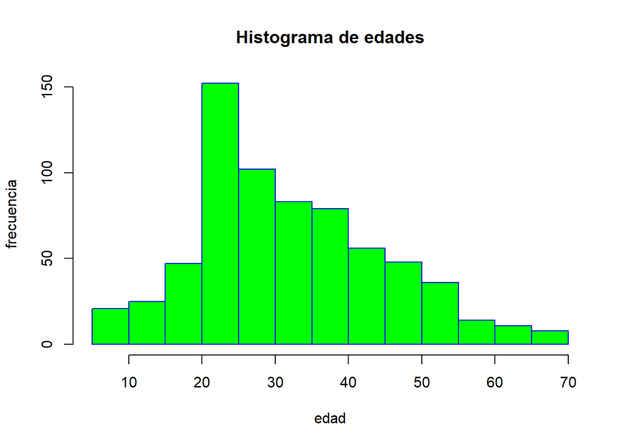

```r
hist(ac$edad,
     main="Histograma de edades",
     xlab="edad",
     ylab="frecuencia",
     border="blue",
     col="green"
     )
```

## Graficos de barras

- Este gráfico busca analizar las diferencias entre el número de victimas hombres y mujeres a lo largo del año

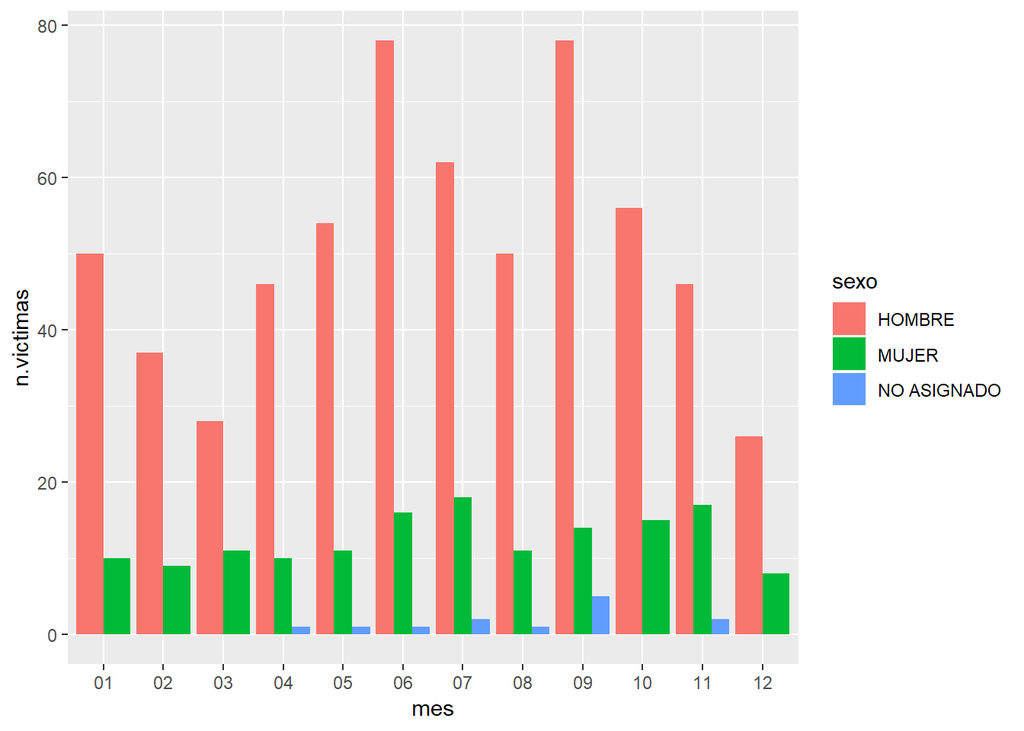

```r
#agrupación por mes y sexo sumando el número de victimas
ac_3 <- y %>%
  group_by(mes, sexo) %>%
  summarize(n.victimas = sum(n_victimas, na.rm = TRUE))

#llamada del grafico
ggplot(data=ac_3, aes(x=mes, y=n.victimas, fill=sexo)) +
  geom_bar(stat="identity", position="dodge")
```

- Este gráfico muestra la evolución de la variable número de victimas a lo largo del año.

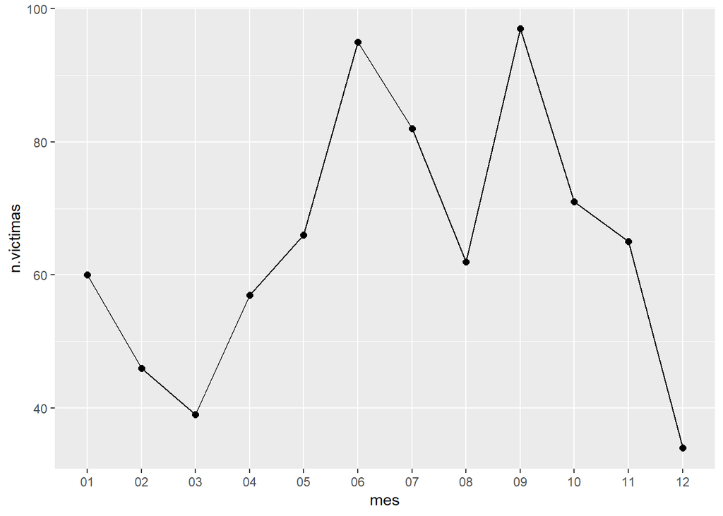

```r
ac_3 <- y %>%
  group_by(mes) %>%
  summarize(n.victimas = sum(n_victimas, na.rm = TRUE))

ggplot(data = ac_3, mapping = aes(x = mes, y = n.victimas, group=1))+
  geom_line()+
  geom_point(colour="black", size=2, shape=21, fill="black")
```